# Actividad 2 Ejercicio 5

CARIS ANDREA CHIA AMAYA - WEIMAR CORTES

2024-09-02

RELACIONES ENTRE LA POTENCIA, EL TAMAÑO DE LOS EFECTOS Y EL TAMAÑO DE LA MUESTRA

# CASO 1

## ANÁLISIS

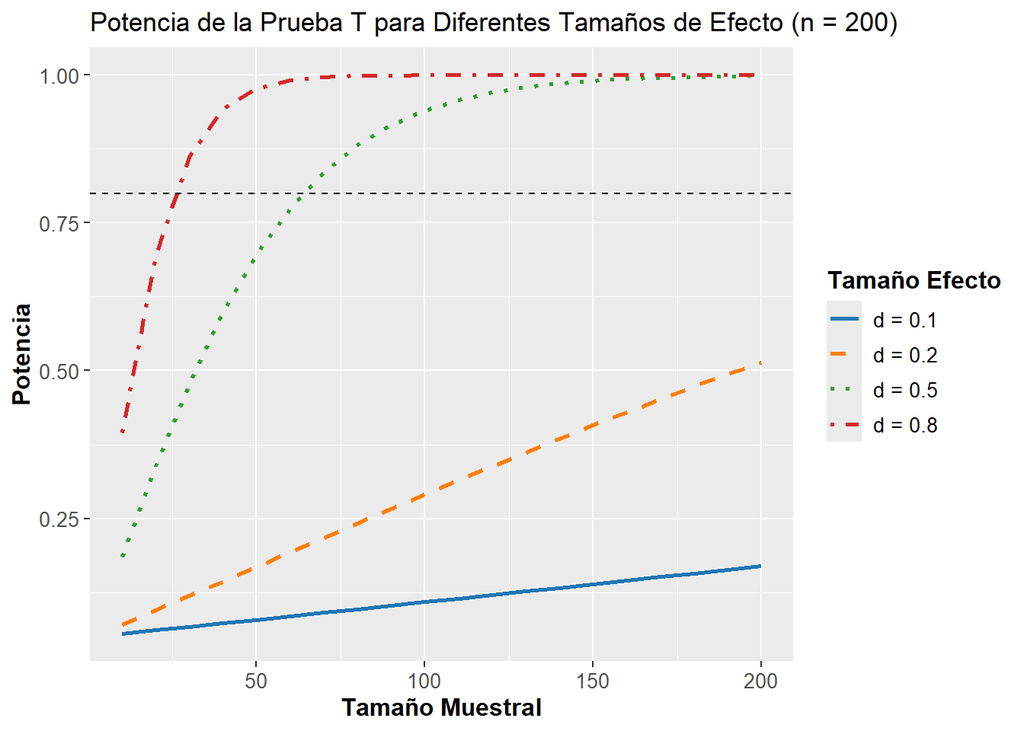

Relación entre Tamaño Muestral y Potencia:

A medida que el tamaño muestral aumenta, la potencia de la prueba también aumenta para todos los tamaños de efecto. Esto significa que con muestras más grandes, es más probable detectar un efecto si realmente existe.

Impacto del Tamaño del Efecto:

Para un tamaño de muestra dado, los efectos más grandes (d=0.8) son más fáciles de detectar (mayor potencia) en comparación con los efectos más pequeños (d=0.1). Esto se refleja en las líneas de la gráfica, donde la línea para d=0.8 alcanza una potencia alta más rápidamente que las líneas para d=0.1, d=0.2 y d=0.5.

Tamaño de Muestra Necesario:

Para alcanzar una potencia deseada (por ejemplo, 0.8), se necesita un tamaño de muestra mayor para detectar efectos más pequeños. Por ejemplo, para un efecto muy pequeño (d=0.1), se requiere un tamaño de muestra mucho mayor que para un efecto grande (d=0.8).

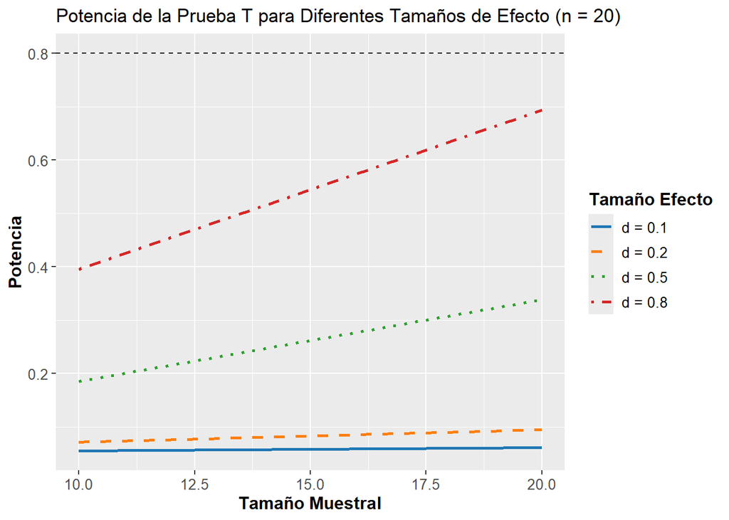

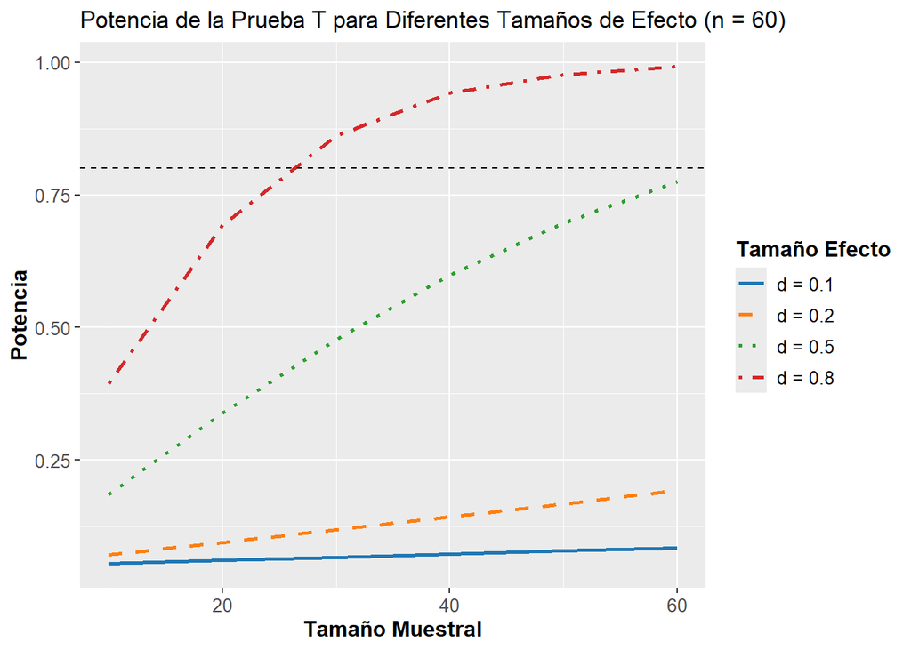

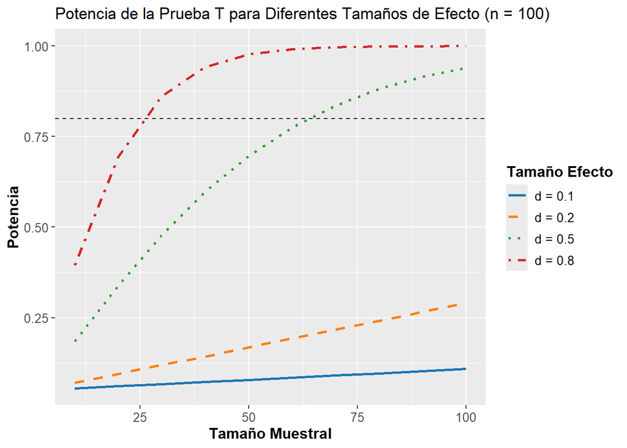

Relación entre Tamaño del Efecto y Potencia:  
Efecto muy pequeño (d=0.1): La potencia sigue siendo baja, aunque mejora en comparación con tamaños muestrales más pequeños. Detectar un efecto tan pequeño sigue siendo difícil. Efecto pequeño (d=0.2): La potencia es mayor que para d=0.1, pero aún no es óptima. Efecto mediano (d=0.5): La potencia es considerablemente alta, lo que sugiere que es probable detectar un efecto de este tamaño con una muestra de 100. Efecto grande (d=0.8): La potencia es muy alta, lo que indica que es muy probable detectar un efecto grande con el tamaño muestral dado.

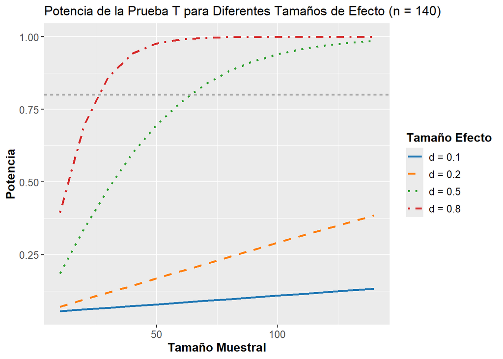

Relación entre Tamaño del Efecto y Potencia:  
Efecto pequeño (d=0.2): La potencia es moderada, pero aún no óptima. Detectar un efecto pequeño sigue siendo un desafío, aunque mejora con el aumento del tamaño muestral. Efecto mediano (d=0.5): La potencia es considerablemente alta, lo que sugiere que es probable detectar un efecto de este tamaño con una muestra de 140. Efecto grande (d=0.8): La potencia es muy alta, lo que indica que es muy probable detectar un efecto grande con el tamaño muestral dado.

## CONCLUSIÓN

Aumento de la Potencia con el Tamaño Muestral:  
En todas las gráficas, se observa que la potencia de la prueba T aumenta a medida que el tamaño muestral incrementa. Esto significa que con muestras más grandes, es más probable detectar un efecto si realmente existe.  
Impacto del Tamaño del Efecto:  
Para un tamaño de muestra dado, los efectos más grandes (por ejemplo, d=0.8) son más fáciles de detectar (mayor potencia) en comparación con los efectos más pequeños (por ejemplo, d=0.1). Esto se refleja en las líneas de las gráficas, donde las líneas para tamaños de efecto más grandes alcanzan una potencia alta más rápidamente que las líneas para tamaños de efecto más pequeños.  
Tamaño de Muestra Necesario:  
Para alcanzar una potencia deseada (por ejemplo, 0.8), se necesita un tamaño de muestra mayor para detectar efectos más pequeños. Por ejemplo, para un efecto muy pequeño (d=0.1), se requiere un tamaño de muestra mucho mayor que para un efecto grande (d=0.8).  
Conclusión General:  
La capacidad de detectar un efecto (potencia) depende tanto del tamaño del efecto como del tamaño muestral. Detectar efectos pequeños requiere muestras más grandes, mientras que los efectos grandes pueden ser detectados con muestras más pequeñas. A medida que el tamaño muestral aumenta, la potencia de la prueba también aumenta, mejorando la probabilidad de detectar efectos de cualquier tamaño.